# Proliferation-Invasion-Recruitment model

Author

Markus Owen

Published

March 10, 2026, 14:27:07

Modified

March 10, 2026, 14:26:53

[Simulating PDGF-Driven Glioma Growth and Invasion in an Anatomically Accurate Brain Domain](https://doi.org/10.1007/s11538-017-0312-3)

```python
# imports and helper functions
import numpy as np
import matplotlib.pyplot as plt

#import an ODE solver
from scipy.integrate import solve_ivp
from scipy.optimize import fsolve

from IPython.display import Markdown

def frexp10(x,n=3):
    exp = int(np.floor(np.log10(abs(x))))
    coeff = round(x / 10**exp, n)
    return '{0}\\times 10^{{1}}'.format(coeff,exp)
```

where

$$\begin{align}
D_c(c,r,p) &= D_c \gamma(c,r,p,p_{auto}) \\[1ex]
D_r(c,r,p) &= D_r \gamma(c,r,p,0) \\[1ex]
\bar{\rho}_c(c,r,p) &= \rho_c \gamma(c,r,p,p_{auto}) \\[1ex]
\bar{\rho}_r(c,r,p) &= \rho_r \gamma(c,r,p,0) \\[1ex]
\gamma(c,r,p,p_auto) &= \frac{\beta(p+p_{auto})}{\beta({EC}_{50})+\beta(p+p_{auto})} \left(1-\frac{c+r}{k}\right) \\[1ex]
\beta(p) &= \frac{p}{k_m+p} \\[1ex]
\alpha &= 1 - \beta(p_{auto})
\end{align}$$

## 0.1 Discretisation of cell movement terms

Considering mesh points $x_i=i \Delta x$, $i=0,1,\dots,N$ with $\Delta x = L/N$, and virtual mesh points half-way between each of these:
$$\begin{align}
\left.\frac{\partial}{\partial x} \left( D_c(c,r,p) \frac{\partial c}{\partial x}\right)\right|_{x_i}
&\approx \frac{\left. D_c(c,r,p) \frac{\partial c}{\partial x} \right|_{x_{i+1/2}} - \left. D_c(c,r,p) \frac{\partial c}{\partial x} \right|_{x_{i-1/2}}}{\Delta x}\\[1ex]
&\approx \frac{\left. D_c(c,r,p)\right|_{x_{i+1/2}} \frac{c(x_{i+1})-c(x_i)}{\Delta x} - \left. D_c(c,r,p) \right|_{x_{i-1/2}} \frac{c(x_{i})-c(x_{i-1})}{\Delta x} }{\Delta x}\\[1ex]
&\approx \frac{\left(\left. D_c(c,r,p)\right|_{x_{i}} + \left. D_c(c,r,p)\right|_{x_{i+1}} \right) (c_{i+1}-c_i) - \left(\left. D_c(c,r,p)\right|_{x_{i-1}} + \left. D_c(c,r,p)\right|_{x_{i}} \right) (c_{i}-c_{i-1}) }{2{\Delta x}^2}\\[1ex]
\end{align}$$

Notice that when $D_c$ is constant we recover the standard second order finite difference scheme for the second derivative.

## 0.2 Set up the model and parameters

### 0.2.1 Define functions

```python
def D_rho_fun(c,r,p,p_auto=0):
    return (beta(p+p_auto)/(beta(EC50)+beta(p+p_auto)))*(1-(c+r)/k)

def beta(p):
    return p/(k_m+p)
```

```python
# define the right-hand side of the ODEs
def pir1d(t, z):
    c = z[0:N]
    r = z[N:2*N]
    p = z[2*N:]

    # c_spatial = D_c*D_rho_fun(c,r,p,p_auto)*(c[im1]-2*c+c[ip1])/dx2
    # r_spatial = D_r*D_rho_fun(c,r,p)*(r[im1]-2*r+r[ip1])/dx2
    # p_spatial = D_p*(p[im1]-2*p+p[ip1])/dx2

    # store the functional part of the diffusion term at mid points of the grid
    # 0-th entry is at dx/2, 1-th is at 3dx/2, 2nd to last L-dx/2, last is also at L-dx/2
    # this makes sense because then approximating a derivative across x=L should give
    # zero as we are implementing zero-flux boundary conditions
    D_rho_c_half = (D_rho_fun(c,r,p,p_auto) + D_rho_fun(c[ip1],r[ip1],p[ip1],p_auto))/2
    D_rho_r_half = (D_rho_fun(c,r,p) + D_rho_fun(c[ip1],r[ip1],p[ip1]))/2
    c_spatial = D_c*(D_rho_c_half*(c[ip1]-c)-D_rho_c_half[im1]*(c-c[im1]))/dx2
    r_spatial = D_r*(D_rho_r_half*(r[ip1]-r)-D_rho_r_half[im1]*(r-r[im1]))/dx2
    p_spatial = D_p*(p[im1]-2*p+p[ip1])/dx2


    return np.concatenate((c_spatial + rho_c*D_rho_fun(c,r,p,p_auto)*c,r_spatial + rho_r*D_rho_fun(c,r,p)*r,p_spatial + eta_c*c - q_c*beta(p)*alpha*c - q_r*beta(p)*r))
```

### 0.2.2 Set up parameters, ICs, etc:

```python
D_c = 0.1
D_r = 0.1
D_p = 1

rho_c = 1
rho_r = 1
k = 1
p_auto = 0
EC50 = 1
k_m = 1

eta_c = 1
q_r = 1
q_c = 1
alpha = 1 - beta(p_auto)

O2a = 1
x0 = 1
infected_fraction = 0.99

N = 101
L = 10

tmax = 10
nplots = 11
```

Parameters from the paper:

```python
D_c = 5.8e-5
D_r = 5.8e-5
D_p = 5e-4

rho_c = np.log(2)/(18/24)
rho_r = np.log(2)/(18/24)
k = 2.3e8
p_auto = 1
EC50 = 10**0.5
k_m = 30

eta_c = 1e-5
q_c = 10**-5.15
q_r = 10**-5.15

O2a = 250/((4/3)*np.pi*0.03**3) # 2210485.3 ~ 2.2e6 in 2018 paper
x0 = 0.03
infected_fraction = 0.99

N = 101
L = 0.35

tmax = 30
nplots = 11
```

### 0.2.3 Define the mesh

```python
dx = L/(N-1)
dx2 = dx**2

xx = np.linspace(0,L,N)
```

Define zero flux indices.

```python
im1 = np.arange(0,N, dtype=np.uint64)-1
im1[0] = 1
ip1 = np.arange(0,N, dtype=np.uint64)+1
ip1[-1] = N-2
```

```python
tspan = [0, tmax]
t_eval = np.linspace(0, tmax, nplots)
rng = np.random.default_rng(1)

c0 = infected_fraction*O2a*(xx<x0)
r0 = (1-infected_fraction)*O2a*(xx<x0) + O2a*(xx>=x0)
p0 = np.zeros(N)

z0 = np.concatenate((c0,r0,p0))

# solve the problem using solve_ivp, storing the solution in sol
# https://docs.scipy.org/doc/scipy/reference/generated/scipy.integrate.solve_ivp.html
sol = solve_ivp(pir1d, tspan, z0, t_eval=t_eval)
```

Plot the solution in space at selected time points

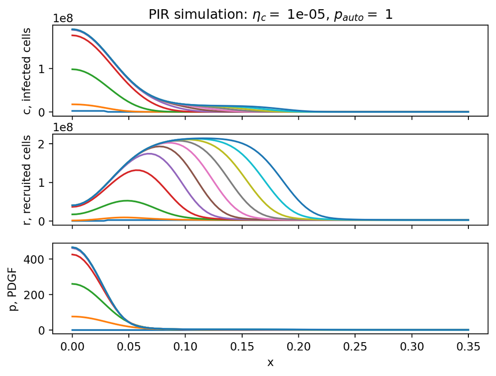

```python
# plot the solution
fig, ax = plt.subplots(3,1,sharex=True)
ax[0].plot(xx,sol.y[0:N,])
ax[0].set_title(r'PIR simulation: $\eta_c =$ %g, $p_{auto} =$ %g' % (eta_c, p_auto))
ax[0].set_ylabel('c, infected cells')

ax[1].plot(xx,sol.y[N:2*N,])
ax[1].set_ylabel('r, recruited cells')

ax[2].plot(xx,sol.y[2*N:,])
ax[2].set_ylabel('p, PDGF')
ax[2].set_xlabel('x')
plt.show()
```

## 0.3 Repeat with larger $\eta_c$, PDGF production

```python
eta_c = 1e-4

tspan = [0, tmax]
t_eval = np.linspace(0, tmax, nplots)
rng = np.random.default_rng(1)

c0 = infected_fraction*O2a*(xx<x0)
r0 = (1-infected_fraction)*O2a*(xx<x0) + O2a*(xx>=x0)
p0 = np.zeros(N)

z0 = np.concatenate((c0,r0,p0))

# solve the problem using solve_ivp, storing the solution in sol
# https://docs.scipy.org/doc/scipy/reference/generated/scipy.integrate.solve_ivp.html
sol = solve_ivp(pir1d, tspan, z0, t_eval=t_eval)
```

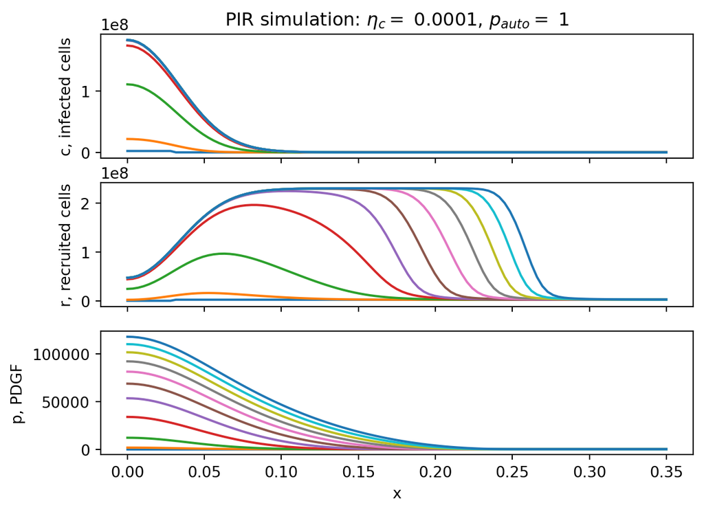

```python
# plot the solution
fig, ax = plt.subplots(3,1,sharex=True)
ax[0].plot(xx,sol.y[0:N,])
ax[0].set_title(r'PIR simulation: $\eta_c =$ %g, $p_{auto} =$ %g' % (eta_c, p_auto))
ax[0].set_ylabel('c, infected cells')

ax[1].plot(xx,sol.y[N:2*N,])
ax[1].set_ylabel('r, recruited cells')

ax[2].plot(xx,sol.y[2*N:,])
ax[2].set_ylabel('p, PDGF')
ax[2].set_xlabel('x')
plt.show()
```

## 0.4 Set $p_{auto}=0$, autocrine behaviour should be included anyway

```python
eta_c = 1e-4
p_auto = 0

tspan = [0, tmax]
t_eval = np.linspace(0, tmax, nplots)
rng = np.random.default_rng(1)

c0 = infected_fraction*O2a*(xx<x0)
r0 = (1-infected_fraction)*O2a*(xx<x0) + O2a*(xx>=x0)
p0 = np.zeros(N)

z0 = np.concatenate((c0,r0,p0))

# solve the problem using solve_ivp, storing the solution in sol
# https://docs.scipy.org/doc/scipy/reference/generated/scipy.integrate.solve_ivp.html
sol = solve_ivp(pir1d, tspan, z0, t_eval=t_eval)
```

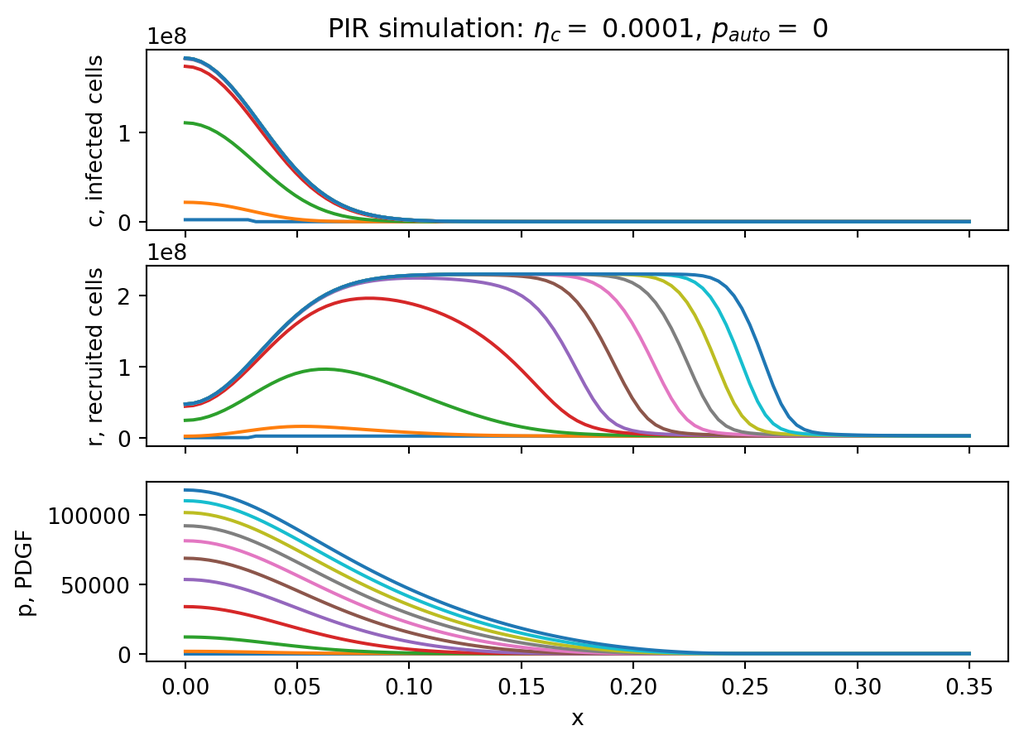

```python
r_max = sol.y[N:2*N,].max()

# plot the solution
fig, ax = plt.subplots(3,1,sharex=True)
ax[0].plot(xx,sol.y[0:N,])
ax[0].set_title(r'PIR simulation: $\eta_c =$ %g, $p_{auto} =$ %g' % (eta_c, p_auto))
ax[0].set_ylabel('c, infected cells')

ax[1].plot(xx,sol.y[N:2*N,])
ax[1].set_ylabel('r, recruited cells')

ax[2].plot(xx,sol.y[2*N:,])
ax[2].set_ylabel('p, PDGF')
ax[2].set_xlabel('x')
plt.show()
```

This is quite similar. We could increase $\eta_c$ a bit to see if it compensates (parameter estimates are not well constrained anyway).

## 0.5 Set $p_{auto}=0$ and $\eta_c=2e-4$

```python
eta_c = 2e-4
p_auto = 0

tspan = [0, tmax]
t_eval = np.linspace(0, tmax, nplots)
rng = np.random.default_rng(1)

c0 = infected_fraction*O2a*(xx<x0)
r0 = (1-infected_fraction)*O2a*(xx<x0) + O2a*(xx>=x0)
p0 = np.zeros(N)

z0 = np.concatenate((c0,r0,p0))

# solve the problem using solve_ivp, storing the solution in sol
# https://docs.scipy.org/doc/scipy/reference/generated/scipy.integrate.solve_ivp.html
sol = solve_ivp(pir1d, tspan, z0, t_eval=t_eval)
```

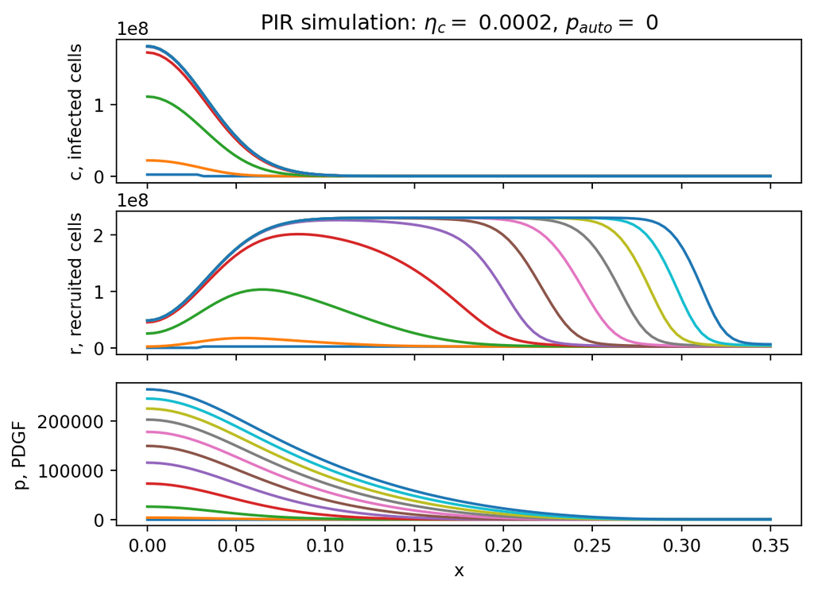

```python
r_max_eta_c_doubled = sol.y[N:2*N,].max()

# plot the solution
fig, ax = plt.subplots(3,1,sharex=True)
ax[0].plot(xx,sol.y[0:N,])
ax[0].set_title(r'PIR simulation: $\eta_c =$ %g, $p_{auto} =$ %g' % (eta_c, p_auto))
ax[0].set_ylabel('c, infected cells')

ax[1].plot(xx,sol.y[N:2*N,])
ax[1].set_ylabel('r, recruited cells')

ax[2].plot(xx,sol.y[2*N:,])
ax[2].set_ylabel('p, PDGF')
ax[2].set_xlabel('x')
plt.show()
```

# 1 Numerical method for the 2D code

From [scmassey/2D_Proliferation-Invasion-Recruitment](https://github.com/scmassey/2D%5fProliferation-Invasion-Recruitment)

`2D_mouse_brain.mat` isn’t in the repo, and this site `http://brainatlas.mbi.ufl.edu` doesn’t exist any more. This repo seems relevant: mouse-brain-atlas.

The method outlined above is similar to that used in [pir_numerics_2d.m](https://github.com/scmassey/2D_Proliferation-Invasion-Recruitment/blob/f61c8ea498fb8617b87c62a29071cd81b0014182/pir_numerics_2d.m#L137) where these interface weights are used in diffusion_op.m.

Above we use that approximation for the diffusion operator at time $t$. In the paper code the approximation is used at times $t$ and $t+\Delta t$, except the $c,r,p$ used in calculating diffusive weights use the old time and the problem remains linear at each time step.

Not sure if it is really Crank-Nicolson as I’m confused about a factor of two.

Notice [Phyllis Nicolson](https://en.wikipedia.org/wiki/Phyllis_Nicolson) of the *Crank-Nicolson* method.